# Project: Country Wealth and Environmental Impact

- Introduction
- Data Wrangling
- Exploratory Data Analysis
- Conclusions

## Introduction

> Today, one of the biggest problems the world is facing is the state of the environment.Climate Change and the warming of the earth will impact everyone and many scientists believe that countries need to act immediately. Yet, when discussing this issue many wonder who is causing the most impact. Is it the rich, developed countries or poorer, undeveloped countries?

> Therefore, the purpose of this project is to use data analytics to help understand the relatioship between wealth and environental impact. Simultaneously,we will also analyze wealth trends and learn how wealth is dispersered throughought the world. To perform this study, we will be using the following indicators obtained from Gapminder database: CO2 emmisions per person(tonnes/person), GNI per captia (Atlas method), Energy production per person ( tonnes of oil equivalent/person), and Percent Agricultural Land. Gapminder provides data over many years for each country.

```python
# Use this cell to set up import statements for all of the packages that you
#   plan to use.
import pandas as pd
import matplotlib.pyplot as plt
import numpy as np


# Remember to include a 'magic word' so that your visualizations are plotted
#   inline with the notebook. See this page for more:
#   http://ipython.readthedocs.io/en/stable/interactive/magics.html
% matplotlib inline
```

## Data Wrangling: Data Restructuring and Merging

### General Properties

```python
# Load your data and print out a few lines. Perform operations to inspect data
#   types and look for instances of missing or possibly errant data.
carbon= pd.read_csv("co2_emissions.csv")
farm= pd.read_csv("agricultural_land.csv")
gni= pd.read_csv("gni.csv")
energy= pd.read_csv("energy_production.csv")
```

### Carbon Emissions

This is how the data for Carbon Emissions looks like loaded from Gapminder. It appears that Gapminder keeps data in a pivot table format. Thus, the data must be restructured.

```python
carbon.head()
```

|  | country | 1800 | 1801 | 1802 | 1803 | 1804 | 1805 | 1806 | 1807 | 1808 | ... | 2005 | 2006 | 2007 | 2008 | 2009 | 2010 | 2011 | 2012 | 2013 | 2014 |
| --- | --- | --- | --- | --- | --- | --- | --- | --- | --- | --- | --- | --- | --- | --- | --- | --- | --- | --- | --- | --- | --- |
| 0 | Afghanistan | NaN | NaN | NaN | NaN | NaN | NaN | NaN | NaN | NaN | ... | 0.0529 | 0.0637 | 0.0854 | 0.154 | 0.242 | 0.294 | 0.412 | 0.35 | 0.316 | 0.299 |
| 1 | Albania | NaN | NaN | NaN | NaN | NaN | NaN | NaN | NaN | NaN | ... | 1.3800 | 1.2800 | 1.3000 | 1.460 | 1.480 | 1.560 | 1.790 | 1.68 | 1.730 | 1.960 |
| 2 | Algeria | NaN | NaN | NaN | NaN | NaN | NaN | NaN | NaN | NaN | ... | 3.2200 | 2.9900 | 3.1900 | 3.160 | 3.420 | 3.300 | 3.290 | 3.46 | 3.510 | 3.720 |
| 3 | Andorra | NaN | NaN | NaN | NaN | NaN | NaN | NaN | NaN | NaN | ... | 7.3000 | 6.7500 | 6.5200 | 6.430 | 6.120 | 6.120 | 5.870 | 5.92 | 5.900 | 5.830 |
| 4 | Angola | NaN | NaN | NaN | NaN | NaN | NaN | NaN | NaN | NaN | ... | 0.9800 | 1.1000 | 1.2000 | 1.180 | 1.230 | 1.240 | 1.250 | 1.33 | 1.250 | 1.290 |

5 rows × 216 columns

```python
# restructure data
carbon=pd.melt(frame=carbon,id_vars=['country'] )
```

```python
#rename columns
carbon.columns= ["Country", "Year", "C02_emissions"]
carbon.head()
```

|  | Country | Year | C02_emissions |
| --- | --- | --- | --- |
| 0 | Afghanistan | 1800 | NaN |
| 1 | Albania | 1800 | NaN |
| 2 | Algeria | 1800 | NaN |
| 3 | Andorra | 1800 | NaN |
| 4 | Angola | 1800 | NaN |

### Percent Agricultural Land

This is how the data for percent agricultural land looks like loaded from Gapminder. It appears that Gapminder keeps data in a pivot table format. Thus, the data must be restructured.

```python
farm.head()
```

|  | country | 1961 | 1962 | 1963 | 1964 | 1965 | 1966 | 1967 | 1968 | 1969 | ... | 2006 | 2007 | 2008 | 2009 | 2010 | 2011 | 2012 | 2013 | 2014 | 2015 |
| --- | --- | --- | --- | --- | --- | --- | --- | --- | --- | --- | --- | --- | --- | --- | --- | --- | --- | --- | --- | --- | --- |
| 0 | Afghanistan | 57.7 | 57.8 | 57.9 | 58.0 | 58.0 | 58.1 | 58.2 | 58.2 | 58.2 | ... | 58.1 | 58.1 | 58.1 | 58.1 | 58.1 | 58.1 | 58.1 | 58.1 | 58.1 | 58.1 |
| 1 | Albania | 45.0 | 45.0 | 45.0 | 44.9 | 45.1 | 45.3 | 45.4 | 45.3 | 45.1 | ... | 40.9 | 40.8 | 43.1 | 43.8 | 43.8 | 43.8 | 43.8 | 43.3 | 42.9 | 42.9 |
| 2 | Algeria | 19.1 | 18.9 | 18.7 | 18.5 | 18.5 | 18.5 | 18.6 | 18.6 | 18.6 | ... | 17.3 | 17.3 | 17.3 | 17.4 | 17.4 | 17.4 | 17.4 | 17.4 | 17.4 | 17.4 |
| 3 | Andorra | 55.3 | 55.3 | 55.3 | 55.3 | 55.3 | 55.3 | 55.3 | 55.3 | 55.3 | ... | 46.3 | 44.2 | 44.2 | 44.2 | 42.1 | 42.1 | 39.9 | 40.0 | 40.0 | 40.0 |
| 4 | Angola | 45.9 | 45.9 | 45.9 | 45.9 | 45.9 | 46.0 | 46.0 | 46.0 | 46.0 | ... | 46.2 | 46.3 | 46.3 | 46.8 | 46.8 | 47.3 | 47.3 | 47.5 | 47.5 | 47.5 |

5 rows × 56 columns

```python
# restructure data
farm=pd.melt(frame=farm,id_vars=['country'] )
```

```python
# rename columns
farm.columns=["Country", "Year", "perct_Farm_Land"]
farm.head()
```

|  | Country | Year | perct_Farm_Land |
| --- | --- | --- | --- |
| 0 | Afghanistan | 1961 | 57.7 |
| 1 | Albania | 1961 | 45.0 |
| 2 | Algeria | 1961 | 19.1 |
| 3 | Andorra | 1961 | 55.3 |
| 4 | Angola | 1961 | 45.9 |

### GNI Per Capita

This is how the data for GNI per capita looks like loaded from Gapminder. It appears that Gapminder keeps data in a pivot table format. Thus, the data must be restructured.

```python
gni.head()
```

|  | country | 1962 | 1963 | 1964 | 1965 | 1966 | 1967 | 1968 | 1969 | 1970 | ... | 2008 | 2009 | 2010 | 2011 | 2012 | 2013 | 2014 | 2015 | 2016 | 2017 |
| --- | --- | --- | --- | --- | --- | --- | --- | --- | --- | --- | --- | --- | --- | --- | --- | --- | --- | --- | --- | --- | --- |
| 0 | Afghanistan | NaN | NaN | NaN | NaN | NaN | NaN | NaN | NaN | NaN | ... | 360.0 | 460.0 | 500.0 | 560.0 | 670.0 | 680.0 | 650.0 | 600.0 | 580.0 | 570.0 |
| 1 | Albania | NaN | NaN | NaN | NaN | NaN | NaN | NaN | NaN | NaN | ... | 3950.0 | 4230.0 | 4360.0 | 4410.0 | 4360.0 | 4540.0 | 4540.0 | 4390.0 | 4320.0 | 4320.0 |
| 2 | Algeria | 190.0 | 230.0 | 240.0 | 240.0 | 230.0 | 250.0 | 280.0 | 310.0 | 330.0 | ... | 4200.0 | 4270.0 | 4460.0 | 4580.0 | 5140.0 | 5480.0 | 5470.0 | 4830.0 | 4360.0 | 3960.0 |
| 3 | Angola | NaN | NaN | NaN | NaN | NaN | NaN | NaN | NaN | NaN | ... | 2760.0 | 3190.0 | 3240.0 | 3390.0 | 3800.0 | 4340.0 | 4440.0 | 4030.0 | 3450.0 | 3330.0 |
| 4 | Antigua and Barbuda | NaN | NaN | NaN | NaN | NaN | NaN | NaN | NaN | NaN | ... | 14100.0 | 12600.0 | 11800.0 | 11500.0 | 11900.0 | 12000.0 | 12500.0 | 12900.0 | 13600.0 | 14200.0 |

5 rows × 57 columns

```python
# restructure and rename
gni=pd.melt(frame=gni,id_vars=['country'] )
gni.columns=["Country", "Year", "GNI"]
gni.head()
```

|  | Country | Year | GNI |
| --- | --- | --- | --- |
| 0 | Afghanistan | 1962 | NaN |
| 1 | Albania | 1962 | NaN |
| 2 | Algeria | 1962 | 190.0 |
| 3 | Angola | 1962 | NaN |
| 4 | Antigua and Barbuda | 1962 | NaN |

### Energy Production Per Person

This is how the data forEnergy production Per Person looks like loaded from Gapminder. It appears that Gapminder keeps data in a pivot table format. Thus, the data must be restructured.

```python
energy.head()
```

|  | country | 1960 | 1961 | 1962 | 1963 | 1964 | 1965 | 1966 | 1967 | 1968 | ... | 2001 | 2002 | 2003 | 2004 | 2005 | 2006 | 2007 | 2008 | 2009 | 2010 |
| --- | --- | --- | --- | --- | --- | --- | --- | --- | --- | --- | --- | --- | --- | --- | --- | --- | --- | --- | --- | --- | --- |
| 0 | Albania | NaN | NaN | NaN | NaN | NaN | NaN | NaN | NaN | NaN | ... | 0.00029 | 0.00031 | 0.00034 | 0.00037 | 0.00037 | 0.00038 | 0.00033 | 0.00036 | 0.00039 | NaN |
| 1 | Algeria | NaN | NaN | NaN | NaN | NaN | NaN | NaN | NaN | NaN | ... | 0.00441 | 0.00455 | 0.00487 | 0.00487 | 0.00507 | 0.00494 | 0.00485 | 0.00471 | 0.00436 | NaN |
| 2 | Angola | NaN | NaN | NaN | NaN | NaN | NaN | NaN | NaN | NaN | ... | 0.00302 | 0.00345 | 0.00333 | 0.00361 | 0.00430 | 0.00470 | 0.00542 | 0.00586 | 0.00544 | NaN |
| 3 | Argentina | NaN | NaN | NaN | NaN | NaN | NaN | NaN | NaN | NaN | ... | 0.00227 | 0.00216 | 0.00222 | 0.00227 | 0.00219 | 0.00221 | 0.00211 | 0.00209 | 0.00202 | NaN |
| 4 | Armenia | NaN | NaN | NaN | NaN | NaN | NaN | NaN | NaN | NaN | ... | 0.00020 | 0.00024 | 0.00023 | 0.00024 | 0.00028 | 0.00028 | 0.00027 | 0.00026 | 0.00027 | NaN |

5 rows × 52 columns

```python
# restructure and rename
energy=pd.melt(frame=energy,id_vars=['country'] )
energy.columns=["Country", "Year", "Energy_Prod"]
energy.head()
```

|  | Country | Year | Energy_Prod |
| --- | --- | --- | --- |
| 0 | Albania | 1960 | NaN |
| 1 | Algeria | 1960 | NaN |
| 2 | Angola | 1960 | NaN |
| 3 | Argentina | 1960 | NaN |
| 4 | Armenia | 1960 | NaN |

### Aligning Years

By observing the data it is clear that the years for the indicators to not match. Therefore, it would be best to align them before merging. By observig the data, we find that the latest year that the data is collected is 1962, and the earliest year data collection stops is 2010. Therefore, we shall cap all indicators to ths time frame.

```python
# take alll data from 1962 on
farm=farm[farm["Year"]>="1962"]
energy=energy[energy["Year"]>="1962"]
carbon=carbon[carbon["Year"]>="1962"]
```

```python
# Find earliest year data collection stops
min(max(carbon["Year"]),max(gni["Year"]),max(energy["Year"]), max(farm["Year"]))
```

```
'2010'
```

```python
# takes data before 2010.
carbon=carbon[carbon["Year"]<="2010"]
farm=farm[farm["Year"]<="2010"]
energy=energy[energy["Year"]<="2010"]
gni=gni[gni["Year"]<="2010"]
```

```python
# reset index
carbon=carbon.reset_index(drop=True)
farm=farm.reset_index(drop=True)
energy=energy.reset_index(drop=True)
gni=gni.reset_index(drop=True)
gni["index"]=gni.index
farm["index"]= farm.index
energy["index"]= energy.index
gni["carbon"]=gni.index
```

Here is how the data looks after restructuring:

```python
energy.head()
```

|  | Country | Year | Energy_Prod | index |
| --- | --- | --- | --- | --- |
| 0 | Albania | 1962 | NaN | 0 |
| 1 | Algeria | 1962 | NaN | 1 |
| 2 | Angola | 1962 | NaN | 2 |
| 3 | Argentina | 1962 | NaN | 3 |
| 4 | Armenia | 1962 | NaN | 4 |

### Joining Indicators

To make further data manipulation and visualization easier, all the indicators must be merged.

```python
# join indicators
table_2=carbon.merge(gni, on=["Country", "Year"]).merge(farm, on=["Country","Year"]).merge(energy, on=["Country", "Year"])
```

```python
table_2.shape
```

```
(6468, 10)
```

Here is how the data loos after joining:

```python
table_2.head()
```

|  | Country | Year | C02_emissions | GNI | index_x | carbon | perct_Farm_Land | index_y | Energy_Prod | index |
| --- | --- | --- | --- | --- | --- | --- | --- | --- | --- | --- |
| 0 | Albania | 1962 | 1.420 | NaN | 1 | 1 | 45.0 | 1 | NaN | 0 |
| 1 | Algeria | 1962 | 0.485 | 190.0 | 2 | 2 | 18.9 | 2 | NaN | 1 |
| 2 | Angola | 1962 | 0.201 | NaN | 3 | 3 | 45.9 | 4 | NaN | 2 |
| 3 | Argentina | 1962 | 2.520 | NaN | 5 | 5 | 49.9 | 6 | NaN | 3 |
| 4 | Armenia | 1962 | 1.360 | NaN | 6 | 6 | NaN | 7 | NaN | 4 |

```python
table_2[table_2["Country"]=="Afghanistan"]
```

|  | Country | Year | C02_emissions | GNI | index_x | carbon | perct_Farm_Land | index_y | Energy_Prod | index |
| --- | --- | --- | --- | --- | --- | --- | --- | --- | --- | --- |

From analyzing this table it is clear that Afghanistan has been excluded because of the join. Therefore, this phenomenon must be further analyzed the see if any other countries have been excluded.

```python
# Take all unique countries from indicators and put them in list. Compare with list of countries from mergeed table
a=np.unique(carbon["Country"]).tolist()
b=np.unique(energy["Country"]).tolist()
c=np.unique(farm["Country"]).tolist()
d=np.unique(gni["Country"]).tolist()
unique_countries=np.unique(np.concatenate((a, b,c,d), axis=None))
np.count_nonzero(unique_countries!=np.unique(table_2["Country"]))
```

```
1
```

Since there is only one discrepency we can conclude the only country excluded was Afghanistan.

We should repeat the same process for Year to see whether our timeframe has remained intact.

```python
# repeat process
a=np.unique(carbon["Year"]).tolist()
b=np.unique(energy["Year"]).tolist()
c=np.unique(farm["Year"]).tolist()
d=np.unique(gni["Year"]).tolist()
unique_year=np.unique(np.concatenate((a, b,c,d), axis=None))
np.count_nonzero(unique_year!=np.unique(table_2["Year"]))
```

```
0
```

It has and every year from 1962 to 2010 has been included.

```python
# drop index columns
table_2=table_2.drop(["index_x", "carbon", "index_y", "index"], axis=1)
```

Here is the final joined table:

```python
table_2.head()
```

|  | Country | Year | C02_emissions | GNI | perct_Farm_Land | Energy_Prod |
| --- | --- | --- | --- | --- | --- | --- |
| 0 | Albania | 1962 | 1.420 | NaN | 45.0 | NaN |
| 1 | Algeria | 1962 | 0.485 | 190.0 | 18.9 | NaN |
| 2 | Angola | 1962 | 0.201 | NaN | 45.9 | NaN |
| 3 | Argentina | 1962 | 2.520 | NaN | 49.9 | NaN |
| 4 | Armenia | 1962 | 1.360 | NaN | NaN | NaN |

## Data Cleaning: Missing Values, Feature Engineering, Duplicates

### Missing Values

```python
# Find location for all missing values in data frame
values=pd.isnull(table_2).values
row,columns=np.where(values==True)
```

```python
table_2.info()
```

```
<class 'pandas.core.frame.DataFrame'>
Int64Index: 6468 entries, 0 to 6467
Data columns (total 6 columns):
Country            6468 non-null object
Year               6468 non-null object
C02_emissions      6173 non-null float64
GNI                4709 non-null float64
perct_Farm_Land    5685 non-null float64
Energy_Prod        4944 non-null float64
dtypes: float64(4), object(2)
memory usage: 353.7+ KB
```

For Country and Year, we have no missing values. There are some missing values for CO2_emissions. However, for the other indicators, there are a significant number of missing values. Also because there are so many, these missing values may not be random.

Visualizing the number of missing values by year and country might provide some insight.

```python
#  Row gives the row location of the missing values. Take all unique rows with missing values and put the year for that row in an array.
array=[]
for i in np.unique(row):
    array.append(table_2.loc[i][1])
```

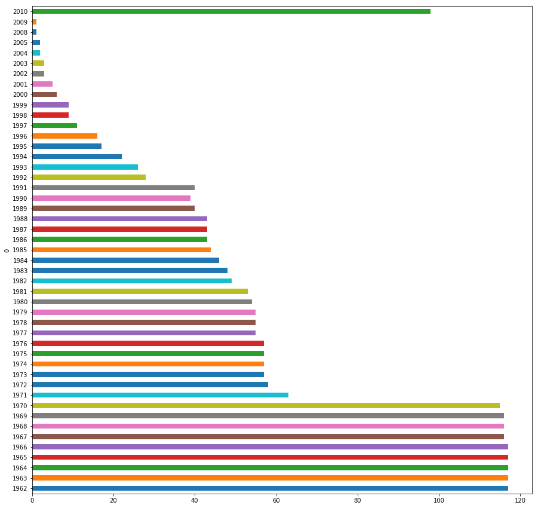

```python
# create bar graph
pd.DataFrame(array).groupby(0).size().plot(kind="barh", figsize=(15,15))
```

This bar graph shows that the missing values are not random. For earlier years, there are a plethora of missing values but for more recent years there is not. However, 2010 seems to be an anomoly.

```python
# repeat for country
array_2=[]
for i in np.unique(row):
    array_2.append(table_2.loc[i][0])
```

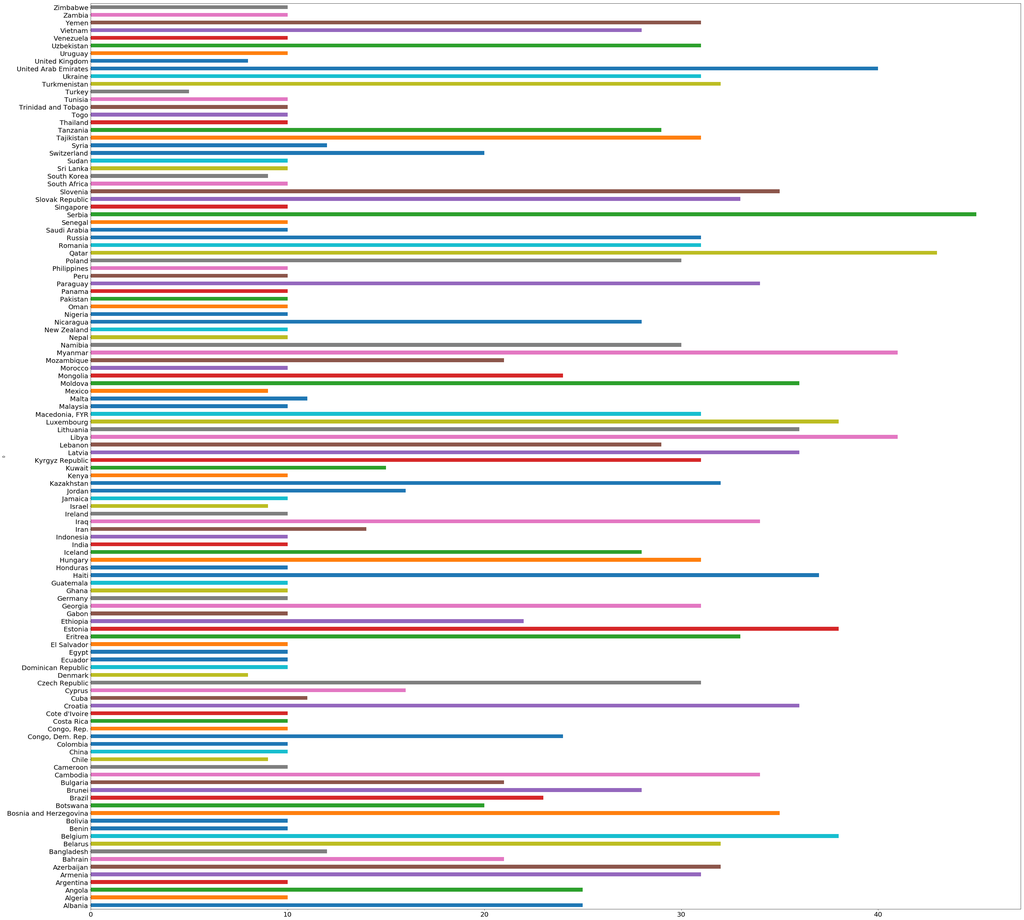

```python
pd.DataFrame(array_2).groupby(0).size().plot(kind="barh", figsize=(50,50), fontsize=20)
```

However, the missing values per country seems to be random and insignificant.

Therefore, from our visualizing, it is apparent that a benificial strategy to help deal with the missing values would be to shortern the timeframe of the project to 1999-2009. Even though this reduces the amount of data, it increases the validity of the research since it minimizes the impact of interpolation.

```python
# Take all values from 1999 to 2009.
table_2["Year"]=table_2["Year"].astype(int)
table_2=table_2[table_2["Year"]>1998]
table_2=table_2[table_2["Year"]<2010]
table_2=table_2.reset_index(drop=True)
```

```python
table_2.info()
```

```
<class 'pandas.core.frame.DataFrame'>
RangeIndex: 1452 entries, 0 to 1451
Data columns (total 6 columns):
Country            1452 non-null object
Year               1452 non-null int64
C02_emissions      1452 non-null float64
GNI                1429 non-null float64
perct_Farm_Land    1443 non-null float64
Energy_Prod        1452 non-null float64
dtypes: float64(4), int64(1), object(1)
memory usage: 68.1+ KB
```

### Interpolation

The previous strategy greatly reduced the number of missing vaues. Now, there are no missing values for Country, Year, CO2 emissions and Energyt Production. Also, there are insignificant amount of missing values for GNI and Agricultural Land. These few missing values can be interpolated by taking the average value of the indicator for the respective country.

```python
table_3=table_2.copy()
```

```python
# interpolate for GNI
table_3['GNI'] = table_3.groupby('Country').GNI.transform(lambda x: x.fillna(x.mean()))
```

```python
# interpolate for Agricultural Land
table_3['perct_Farm_Land'] = table_3.groupby('Country').perct_Farm_Land.transform(lambda x: x.fillna(x.mean()))
```

```python
table_3.info()
```

```
<class 'pandas.core.frame.DataFrame'>
RangeIndex: 1452 entries, 0 to 1451
Data columns (total 6 columns):
Country            1452 non-null object
Year               1452 non-null int64
C02_emissions      1452 non-null float64
GNI                1452 non-null float64
perct_Farm_Land    1452 non-null float64
Energy_Prod        1452 non-null float64
dtypes: float64(4), int64(1), object(1)
memory usage: 68.1+ KB
```

There are now no missing values!

### Feature Engineering

To analyze wealth trends and its relationship with the indcators, it would be benificial classify each country based on its wealth. The World Bank has a wealth classification system that utilizes GNI/capita.

The World Bank defines high-income nations as having a GNI of at least 12,276 dollars per capita, defines lower middle income countries as having a GNI that ranges from 1,006 to 3,975 dollars per capita and upper middle income countries as having a GNI ranging from 3,976 to 12,275 dollars per capita. Any country below 1,006 dollars per capita is low-income.

```python
# implement Wealth Classification
classifications=[]
for i in table_3["GNI"]:
    if i >12275:
        x= "high_income"
    elif 3975 <i <12276:
        x="upper_middle_income"
    elif 3976>i>1005:
        x="lower_middle_income"
    elif i<1006:
        x="low_income"
    classifications.append(x)
```

```python
# Add to Dataframe
table_3["Income_classification"]= classifications
```

### Duplicate Values

There are no Duplicated Values in the dataset.

```python
sum(table_3.duplicated())
```

```
0
```

```python
clean=table_3
```

Here is the cleaned table:

```python
clean.head()
```

|  | Country | Year | C02_emissions | GNI | perct_Farm_Land | Energy_Prod | Income_classification |
| --- | --- | --- | --- | --- | --- | --- | --- |
| 0 | Albania | 1999 | 0.958 | 1010.0 | 41.8 | 0.00035 | lower_middle_income |
| 1 | Algeria | 1999 | 2.990 | 1530.0 | 16.7 | 0.00455 | lower_middle_income |
| 2 | Angola | 1999 | 0.574 | 330.0 | 46.0 | 0.00322 | low_income |
| 3 | Argentina | 1999 | 4.010 | 7540.0 | 46.9 | 0.00219 | upper_middle_income |
| 4 | Armenia | 1999 | 0.976 | 610.0 | 46.5 | 0.00021 | low_income |

## Exploratory Data Analysis

> **Tip**: Now that you've trimmed and cleaned your data, you're ready to move on to exploration. Compute statistics and create visualizations with the goal of addressing the research questions that you posed in the Introduction section. It is recommended that you be systematic with your approach. Look at one variable at a time, and then follow it up by looking at relationships between variables.

### Research Topic 1: Understanding the Distrubution of Wealth

### How has the distribution of wealthy countries/ less wealthy countries changed over time?

```python
# Group by Income Classification and Year. Take the number of countries in each income level for each year, and put in array
x=pd.DataFrame(clean.groupby(["Income_classification", "Year"]).size())
year= np.unique(clean["Year"])
high_income= []
for i in np.arange(11):
    high_income.append(x[0][i])
low_income= []
for i in np.arange(11,22):
    low_income.append(x[0][i])
lower_middle_income= []
for i in np.arange(22,33):
    lower_middle_income.append(x[0][i])
upper_middle_income= []
for i in np.arange(33,44):
    upper_middle_income.append(x[0][i])
```

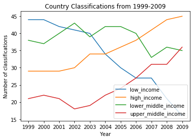

```python
# plot array
plt.plot(year, low_income, label="low_income")
plt.plot(year, high_income, label="high_income")
plt.plot(year, lower_middle_income, label="lower_middle_income")
plt.plot(year, upper_middle_income,label= "upper_middle_income")
plt.title("Country Classifications from 1999-2009")
plt.xlabel("Year")
plt.ylabel("Number of classifications")
plt.xticks(year);
plt.legend();
plt.figure(figsize=(100,100));
```

Over this ten year period, the number of low income countries has decreased rapidly. The number of lower middle income countries also decreased. However, the number of high income and upper middle income countries has increased. This graph depicts an interesting phenomenon. In the beginning of the period, there were more poorer countries than wealther countries. Yet, by the end of the period, the distribution had changed completely. This indicates that the world is getting wealthier.

### Is the wealth concentrated in a few countries or distributed evenly?

```python
total=clean.groupby("Year").sum()["GNI"]
```

```python
# Create a new proportion column which is GNI for one country/ sum of all GNI
porportion=[]
for i in range(1452):
    x= clean.loc[i][3]/total.loc[clean.loc[i][1]]
    porportion.append(x)
```

```python
clean["GNI_proportion"]= porportion
```

```python
# Sort based on GNI, and take a cumulatve sum for the new GNI_proportion. Check how many coumns it takes to get to .5. Repeat
number=[]
year= np.unique(clean["Year"])
for i in year:
    cumulative=clean[clean["Year"]==i].sort_values(by="GNI_proportion",ascending=False).cumsum()[["Country","GNI_proportion"]]
    x=len(cumulative[cumulative["GNI_proportion"]<0.5])
    number.append(x)
```

```python
# Convert numbers in array to percents
x=np.array(number).astype(int)
x.astype(int)
percent= (x/132)*100
```

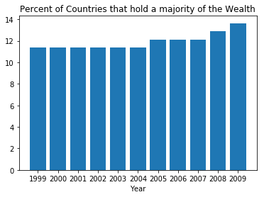

```python
# Plot
plt.bar(x=year, height= percent)
plt.xticks(year);
plt.title("Percent of Countries that hold a majority of the Wealth")
plt.xlabel("Year")
plt.ylabel=("Percent")
```

The Wealth for the world is concentrated in a few countries. From 1999 to 2003, about 11 % of the countries had a majority of the wealth. However, this number increased slighly to about 14% in 2009.

### Research Topic 2 Impact on Environment

### How has the trend changed overtime for the Environmental Indicators?

```python
clean.head()
```

|  | Country | Year | C02_emissions | GNI | perct_Farm_Land | Energy_Prod | Income_classification |
| --- | --- | --- | --- | --- | --- | --- | --- |
| 0 | Albania | 1999 | 0.958 | 1010.0 | 41.8 | 0.00035 | lower_middle_income |
| 1 | Algeria | 1999 | 2.990 | 1530.0 | 16.7 | 0.00455 | lower_middle_income |
| 2 | Angola | 1999 | 0.574 | 330.0 | 46.0 | 0.00322 | low_income |
| 3 | Argentina | 1999 | 4.010 | 7540.0 | 46.9 | 0.00219 | upper_middle_income |
| 4 | Armenia | 1999 | 0.976 | 610.0 | 46.5 | 0.00021 | low_income |

### Carbon Emissions

The average CO2 emissions/person had increased from 1999 to 2008. However, it decreased drastically in 2009.

```
Text(0,0.5,'tonnes per person')
```

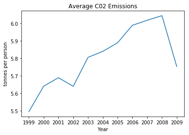

```python
clean.groupby("Year").mean()[ "C02_emissions"].plot()
plt.title("Average C02 Emissions")
plt.xticks(np.unique(clean["Year"]))
plt.xlabel("Year")
plt.ylabel("tonnes per person")
```

### Agricultural Land

The average Percent Agricultural Land has decreased throughout the time period.

```
Text(0,0.5,'%')
```

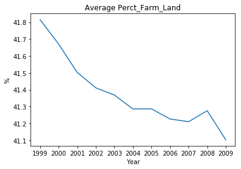

```python
clean.groupby("Year").mean()[ "perct_Farm_Land"].plot()
plt.title("Average Perct_Farm_Land")
plt.xticks(np.unique(clean["Year"]))
plt.xlabel("Year")
plt.ylabel("%")
```

### Energy production

The average Energy Production per person seems to follow a parobola. It increased from 1999 to 2003, reached a peak at 2004, and decreased from 2005 to 2009.

```
Text(0,0.5,'tonnes of oil equivalent per person')
```

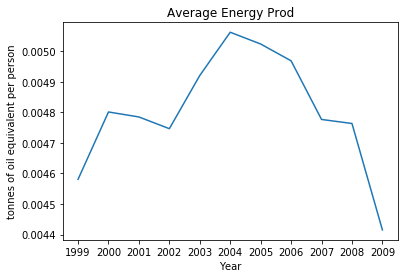

```python
clean.groupby("Year").mean()[ "Energy_Prod"].plot()
plt.title("Average Energy Prod")
plt.xticks(np.unique(clean["Year"]))
plt.xlabel("Year")
plt.ylabel("tonnes of oil equivalent per person")
```

### How do these environmental indicators correlate with GNI?

```python
# Take all CO2 emissions for each year, and GNI numbers for each year.
x1=clean[clean["Year"]==1999]["C02_emissions"]
x2=clean[clean["Year"]==2000]["C02_emissions"]
x3=clean[clean["Year"]==2001]["C02_emissions"]
x4=clean[clean["Year"]==2002]["C02_emissions"]
x5=clean[clean["Year"]==2003]["C02_emissions"]
x6=clean[clean["Year"]==2004]["C02_emissions"]
x7=clean[clean["Year"]==2005]["C02_emissions"]
x8=clean[clean["Year"]==2006]["C02_emissions"]
x9=clean[clean["Year"]==2007]["C02_emissions"]
x10=clean[clean["Year"]==2008]["C02_emissions"]
x11=clean[clean["Year"]==2009]["C02_emissions"]
y1=clean[clean["Year"]==1999]["GNI"]
y2=clean[clean["Year"]==2000]["GNI"]
y3=clean[clean["Year"]==2001]["GNI"]
y4=clean[clean["Year"]==2002]["GNI"]
y5=clean[clean["Year"]==2003]["GNI"]
y6=clean[clean["Year"]==2004]["GNI"]
y7=clean[clean["Year"]==2005]["GNI"]
y8=clean[clean["Year"]==2006]["GNI"]
y9=clean[clean["Year"]==2007]["GNI"]
y10=clean[clean["Year"]==2008]["GNI"]
y11=clean[clean["Year"]==2009]["GNI"]

# Function Creates a series of scatter subplots which compare the relationhip between two variables.
# It also calculates the correlation coefficient.

def plot(x1,x2,x3,x4,x5,x6,x7,x8,x9,x10,x11,y1,y2,y3,y4,y5,y6,y7,y8,y9,y10,y11,name,labelx,labely,x,y):
    plt.figure(figsize=(23,23))
    plt.subplot(3, 4, 1)

    plt.scatter(x1, y1)
    plt.title("1999:"+" "+name)
    plt.xlabel(labelx)
    plt.ylabel(labely)
    plt.text(x=x,y=y,s="r"+":"+" "+str(round(np.corrcoef(x1,y1)[0][1],3)), fontsize=15)


    plt.subplot(3, 4, 2)
    plt.scatter(x2, y2)
    plt.title("2000:"+" "+name)
    plt.xlabel(labelx)
    plt.ylabel(labely)
    plt.text(x=x,y=y,s="r"+":"+" "+str(round(np.corrcoef(x2,y2)[0][1],3)), fontsize=15)

    plt.subplot(3,4, 3)
    plt.scatter(x3, y3)
    plt.title("2001:"+" "+name)
    plt.xlabel(labelx)
    plt.ylabel(labely)
    plt.text(x=x,y=y,s="r"+":"+" "+str(round(np.corrcoef(x3,y3)[0][1],3)), fontsize=15)

    plt.subplot(3, 4, 4)
    plt.scatter(x4, y4)
    plt.title("2002:"+" "+name)
    plt.xlabel(labelx)
    plt.ylabel(labely)
    plt.text(x=x,y=y,s="r"+":"+" "+str(round(np.corrcoef(x4,y4)[0][1],3)), fontsize=15)

    plt.subplot(3, 4, 5)
    plt.scatter(x5, y5)
    plt.title("2003:"+" "+name)
    plt.xlabel(labelx)
    plt.ylabel(labely)
    plt.text(x=x,y=y,s="r"+":"+" "+str(round(np.corrcoef(x5,y5)[0][1],3)), fontsize=15)

    plt.subplot(3, 4, 6)
    plt.scatter(x6, y6)
    plt.title("2004:"+" "+name)
    plt.xlabel(labelx)
    plt.ylabel(labely)
    plt.text(x=x,y=y,s="r"+":"+" "+str(round(np.corrcoef(x6,y6)[0][1],3)), fontsize=15)

    plt.subplot(3,4, 7)
    plt.scatter(x7, y7)
    plt.title("2005:"+" "+name)
    plt.xlabel(labelx)
    plt.ylabel(labely)
    plt.text(x=x,y=y,s="r"+":"+" "+str(round(np.corrcoef(x7,y7)[0][1],3)), fontsize=15)

    plt.subplot(3, 4, 8)
    plt.scatter(x8, y8)
    plt.title("2006:"+" "+name)
    plt.xlabel(labelx)
    plt.ylabel(labely)
    plt.text(x=x,y=y,s="r"+":"+" "+str(round(np.corrcoef(x8,y8)[0][1],3)), fontsize=15)

    plt.subplot(3, 4, 9)
    plt.scatter(x9, y9)
    plt.title("2007:"+" "+name)
    plt.xlabel(labelx)
    plt.ylabel(labely)
    plt.text(x=x,y=y,s="r"+":"+" "+str(round(np.corrcoef(x9,y9)[0][1],3)), fontsize=15)

    plt.subplot(3,4, 10)
    plt.scatter(x10, y10)
    plt.title("2008:"+" "+name)
    plt.xlabel(labelx)
    plt.ylabel(labely)
    plt.text(x=x,y=y,s="r"+":"+" "+str(round(np.corrcoef(x10,y10)[0][1],3)), fontsize=15)

    plt.subplot(3, 4, 11)
    plt.scatter(x11, y11)
    plt.title("2009:"+" "+name)
    plt.xlabel(labelx)
    plt.ylabel(labely)
    plt.text(x=x,y=y,s="r"+":"+" "+str(round(np.corrcoef(x11,y11)[0][1],3)), fontsize=15)

    return print(labelx)
```

### Carbon Emissions

```
CO2
```

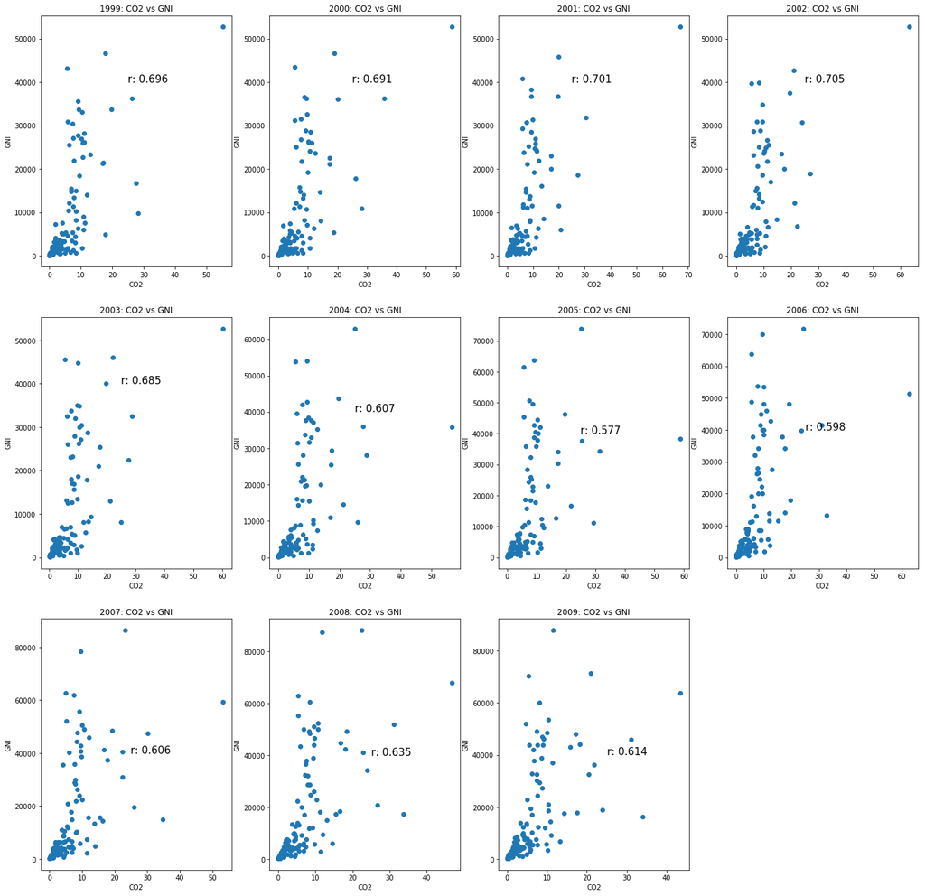

```python
plot(x1,x2,x3,x4,x5,x6,x7,x8,x9,x10,x11,y1,y2,y3,y4,y5,y6,y7,y8,y9,y10,y11,"CO2 vs GNI","CO2","GNI",25,40000)
```

### Agricultural Land

```
Farmland
```

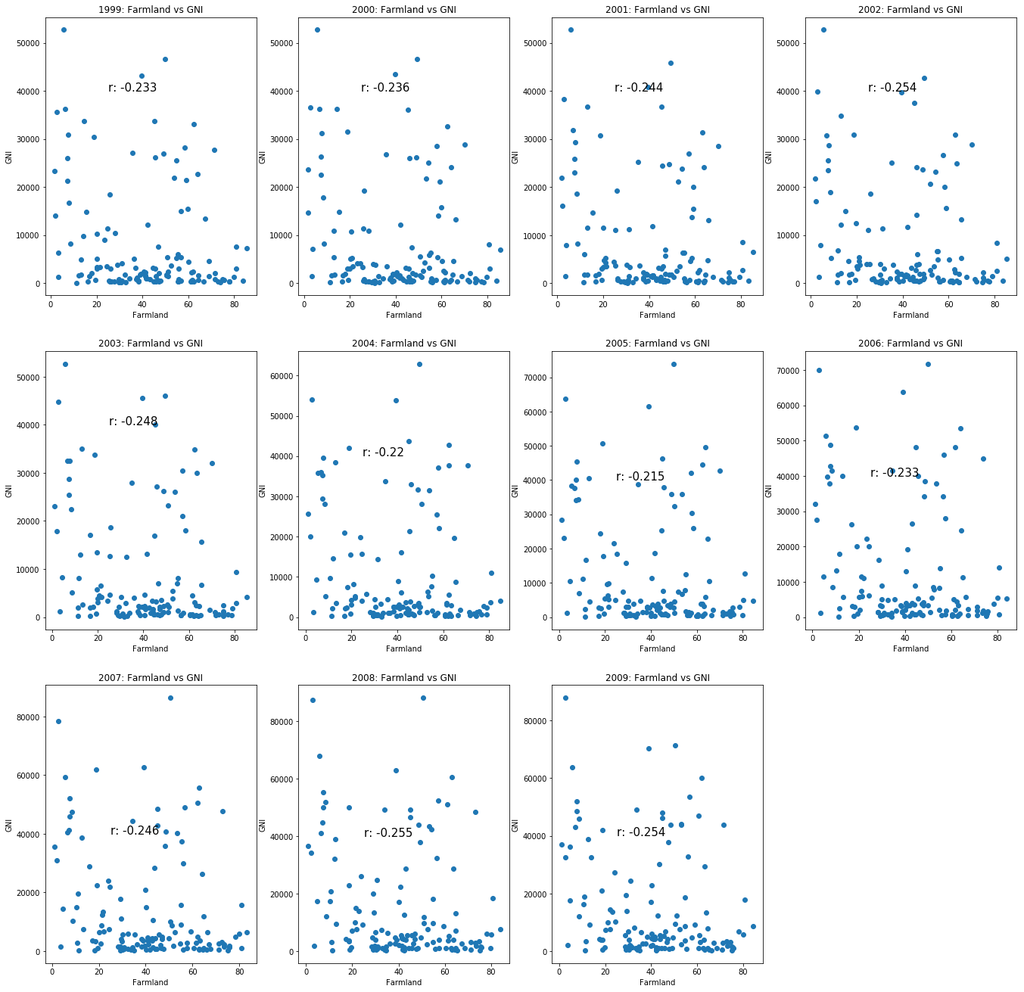

```python
# Redefine X Values and call plot function
x1=clean[clean["Year"]==1999]["perct_Farm_Land"]
x2=clean[clean["Year"]==2000]["perct_Farm_Land"]
x3=clean[clean["Year"]==2001]["perct_Farm_Land"]
x4=clean[clean["Year"]==2002]["perct_Farm_Land"]
x5=clean[clean["Year"]==2003]["perct_Farm_Land"]
x6=clean[clean["Year"]==2004]["perct_Farm_Land"]
x7=clean[clean["Year"]==2005]["perct_Farm_Land"]
x8=clean[clean["Year"]==2006]["perct_Farm_Land"]
x9=clean[clean["Year"]==2007]["perct_Farm_Land"]
x10=clean[clean["Year"]==2008]["perct_Farm_Land"]
x11=clean[clean["Year"]==2009]["perct_Farm_Land"]
plot(x1,x2,x3,x4,x5,x6,x7,x8,x9,x10,x11,y1,y2,y3,y4,y5,y6,y7,y8,y9,y10,y11,"Farmland vs GNI","Farmland","GNI",25,40000)
```

### Energy Production

The scatter plost show that Enegry Production is positivly correlated with GNi, though not as strong as Carbon Emissions, as the R values range from .335 to .487. Similar, to CO2 emissions, we also notice the presence of outliers, with a few wealthy countries producing a significant amount of energy/person.

```
Energy production
```

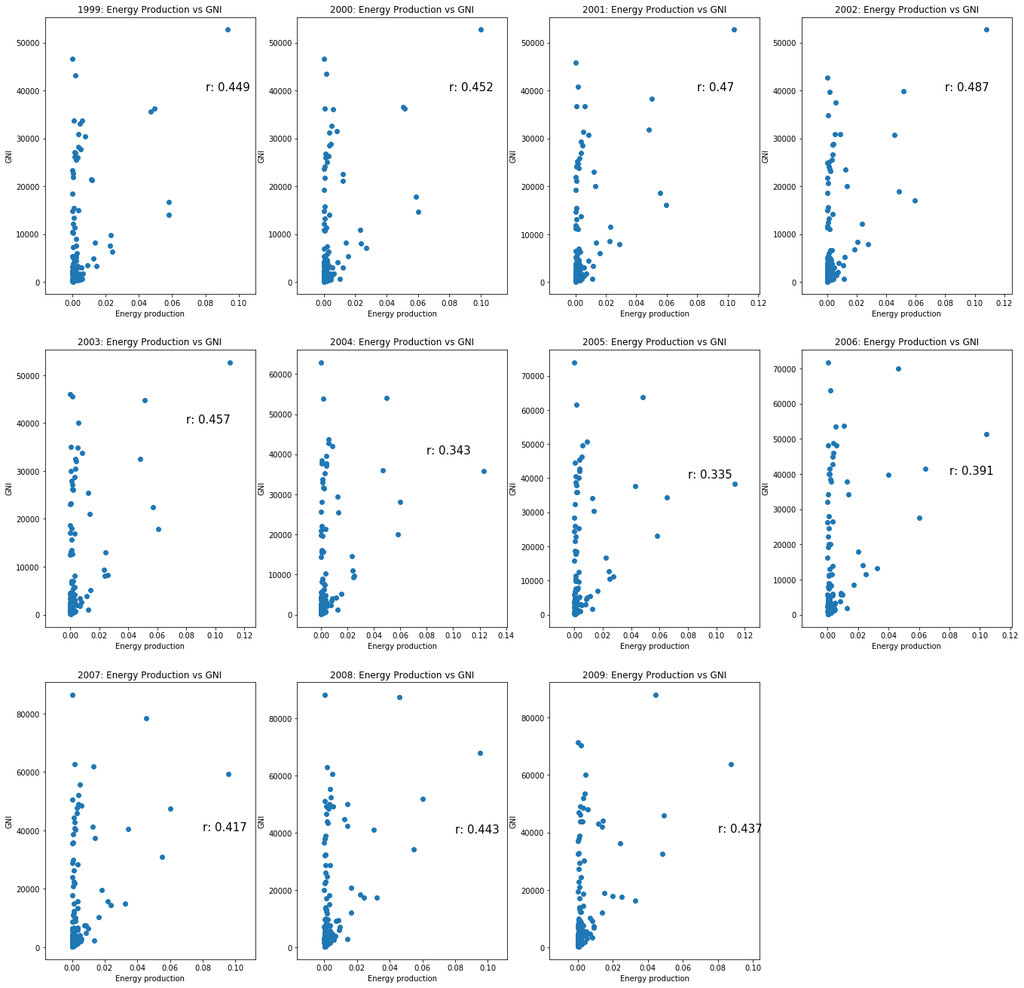

```python
x1=clean[clean["Year"]==1999]["Energy_Prod"]
x2=clean[clean["Year"]==2000]["Energy_Prod"]
x3=clean[clean["Year"]==2001]["Energy_Prod"]
x4=clean[clean["Year"]==2002]["Energy_Prod"]
x5=clean[clean["Year"]==2003]["Energy_Prod"]
x6=clean[clean["Year"]==2004]["Energy_Prod"]
x7=clean[clean["Year"]==2005]["Energy_Prod"]
x8=clean[clean["Year"]==2006]["Energy_Prod"]
x9=clean[clean["Year"]==2007]["Energy_Prod"]
x10=clean[clean["Year"]==2008]["Energy_Prod"]
x11=clean[clean["Year"]==2009]["Energy_Prod"]
plot(x1,x2,x3,x4,x5,x6,x7,x8,x9,x10,x11,y1,y2,y3,y4,y5,y6,y7,y8,y9,y10,y11,"Energy Production vs GNI","Energy production","GNI",.08,40000)
```

### How does environmental impact differ by Wealth Classifiication?

```python
clean.drop("Year", axis=1).groupby(["Income_classification"]).mean()
```

| Income_classification | C02_emissions | GNI | perct_Farm_Land | Energy_Prod |
| --- | --- | --- | --- | --- |
| high_income | 12.970771 | 32114.324479 | 33.300977 | 0.012204 |
| low_income | 0.922085 | 522.933743 | 47.833880 | 0.000796 |
| lower_middle_income | 2.991000 | 2270.600000 | 43.888106 | 0.001702 |
| upper_middle_income | 6.499485 | 6833.204044 | 40.319301 | 0.004461 |

This table, which depicts the average vaue of the indicators based on income classification confirms the notion that CO2 emissions, GNI and Energy production are concentrated in wealth countries. The large differences between high income and low income observed could be attributed to the previously observed phenomena of concentration and outliers.

## Conclusions

> From this study, we observed a trend which suggests that the world is becoming wealthier. Also, it seems like the majority of the world's wealth is concentrated in a few countries. From the environmental indicators observed, we see an overall increase in CO2 emmissions, a decrease in Farmland, and a parabolic trend for energy production. When observing the scatter plots and r values between the environmental idicators, we noticed a strong positive correlation between GNI and CO2 emissions, a positive correlation between GNI and energy production, and a weak negative correlation between farmland and GNI. Also, by observing the scatter plots we noticed the presence of outliers for CO2 emissions and Energy production, which could suggest the that a majority of CO2 emssions and Energy Production is with the Wealthy Countries. This phenomea was also observed by analyzing the average values based on the Wealth Classification. Going forward, it would be benificial to conduct statistical tests like p-value to determine whether the results are statistically significant.

## Submitting your Project

> Before you submit your project, you need to create a .html or .pdf version of this notebook in the workspace here. To do that, run the code cell below. If it worked correctly, you should get a return code of 0, and you should see the generated .html file in the workspace directory (click on the orange Jupyter icon in the upper left).

> Alternatively, you can download this report as .html via the **File** > **Download as** submenu, and then manually upload it into the workspace directory by clicking on the orange Jupyter icon in the upper left, then using the Upload button.

> Once you've done this, you can submit your project by clicking on the "Submit Project" button in the lower right here. This will create and submit a zip file with this .ipynb doc and the .html or .pdf version you created. Congratulations!

```python
from subprocess import call
call(['python', '-m', 'nbconvert', 'Investigate_a_Dataset.ipynb'])
```